# Extra - Hypothsis testing

- Show All Code
- Hide All Code
- View Source

Published

July 22, 2024

## Extra activity 1: multiple testing correction

When we test the same hypothesis multiple times, for example if we have 10.000 genes and we ask which have a difference in expression in one condition or the other, we can find some significant hits by chance; because we are testing multiple times. With a higher number of tests, the probability of finding a significant hit by chance increases.

We can use the p-value histogram plot for diagnostic purposes.

1. We create a dataset with 4 samples, two controls and two treatment, simulated using `rnorm`. Each one with sample size 10.000, mean 0 and sd 1.  
   The alternative hypothesis states that mean and variance in the two conditions are different - the genes are differentially expressed.  
   We can use a function that computes t-test for rows in a matrix, that is called `rowttests`; and we extract the pvalues and we plot them. The result should look like this

Try yourself first! And if you struggle, you can look at the code

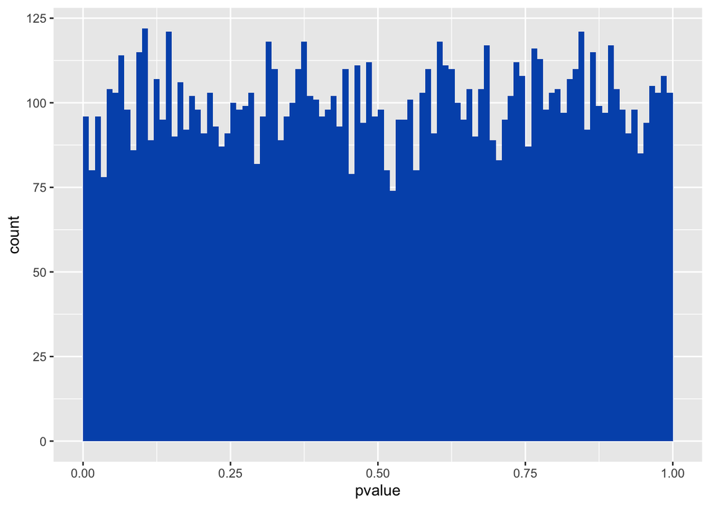

```r
set.seed(300)

# rnorm is a function that simulates a normal distribution,
# sampling 10000 numbers, from a distribution of mean 0 and variance 1
# All 4 samples (2 Controls and 2 Treated) have the same mean
y = cbind(Control = rnorm(10000, 0, 1),
          Control = rnorm(10000, 0, 1),
          Treatment = rnorm(10000, 0, 1),
          Treatment = rnorm(10000, 0, 1))

pvalue = rowttests(y, factor(c("Control","Control","Treatment","Treatment")))$p.value

#hist(pvalue, breaks = 50, col= "#0056B9")
ggplot(tibble(pvalue), aes(x = pvalue)) +
  geom_histogram(binwidth = 0.01, fill = "#0056B9", boundary = 0)
```

How many pvalues are < 0.05?

```r
# TODO
```

In this case all pvalues are background because there is not difference between control and treatment.

#### Understanding the batch effect:

Now let’s assume that two samples were processed on the same day separately from the others. That day, something happened and the means in both samples were shifted. In that case, the histogram is skewed to the right.

1. Imagine that one control and one treatment were processed on the same day and for some reason their mean are shifted to the right, even though there should be no difference
2. run the t-test again
3. plot, how does it look like?

One way to take such batch effects into account is by adding the batch factor (e.g. the run day) in our model as covariate.

#### Simulating differentially expressed

Now let’s simulate and look at how it would be if they were really differentially expressed.

1. Repeat the lines above and simulate so that there is a difference in the means between the 2 controls and the 2 treated samples are differentially expressed:
2. run the t-test again
3. plot, how does it look like?